# Lecture10

# Introduction

This is a simple illustration of the data analysis workflow and it shows how we basically handle data to solve the real problem.

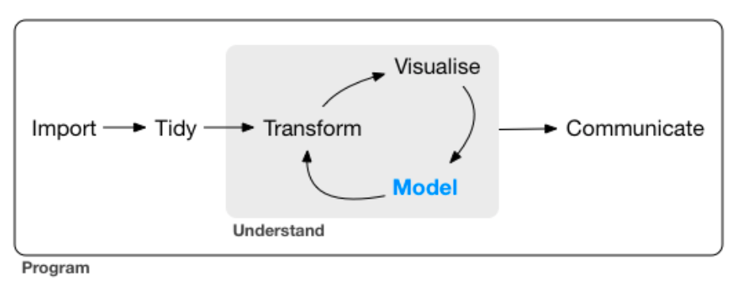

1 Probability

2 Simulation

3 Statistical Test

# The Normal Distribution

## The Normal Distribution Functions in R

```r
dnorm(x, mean = 0, sd = 1, log = FALSE)
pnorm(q, mean = 0, sd = 1, lower.tail = TRUE, log.p = FALSE)
qnorm(p, mean = 0, sd = 1, lower.tail = TRUE, log.p = FALSE)
rnorm(n, mean = 0, sd = 1)
```

## Description

1 dnorm gives the density,

2 pnorm gives the distribution function,

3 qnorm gives the quantile function, and

4 rnorm generates random deviates.

## Plot density and distribution functions using dnorm and pnorm

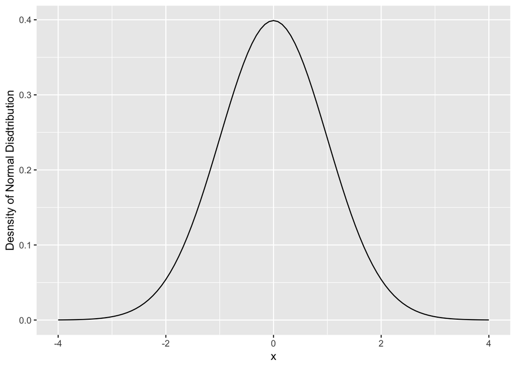

```r
  # Plot the normal density
ggplot(data = data.frame(x = c(-4, 4)), aes(x)) +
  stat_function(fun = dnorm, args = list(mean = 0, sd = 1)) +
  ylab("Desnsity of Normal Disdtribution")
```

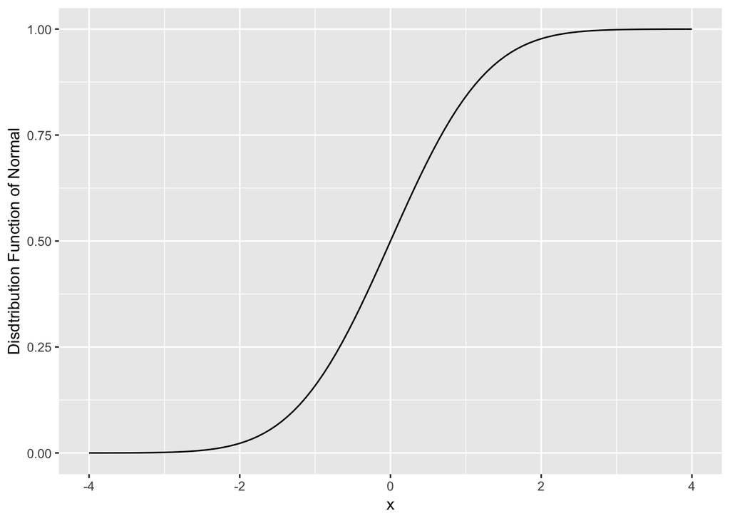

```r
# Plot the distribution function of normal
ggplot(data = data.frame(x = c(-4, 4)), aes(x)) +
  stat_function(fun = pnorm, args = list(mean = 0, sd = 1)) +
  ylab("Disdtribution Function of Normal")
```

## Understanding standard Normal

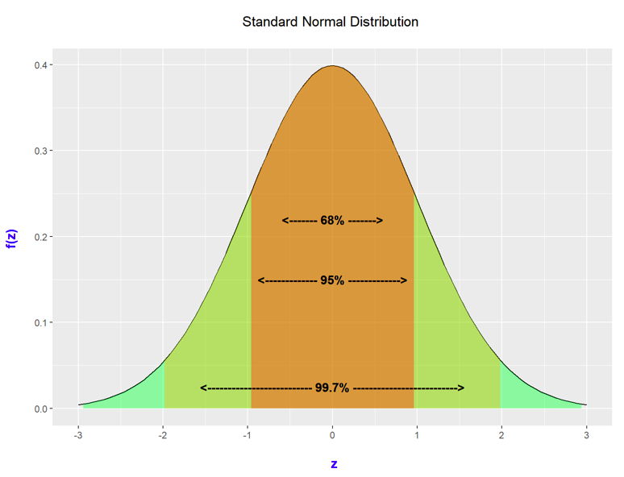

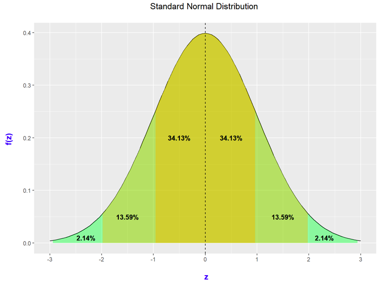

## Using pnorm

```r
#P(X <= 85)
pnorm(q = 85, mean = 75, sd = 5, lower.tail = TRUE)
```

```
## [1] 0.9772499
```

```r
#P(X >= 85)
pnorm(q = 85, mean = 75, sd = 5, lower.tail = FALSE)
```

```
## [1] 0.02275013
```

```r
#z score, P(Z <= 2)
pnorm(q = 2, mean = 0, sd = 1, lower.tail = TRUE)
```

```
## [1] 0.9772499
```

```r
pnorm(q = 2)
```

```
## [1] 0.9772499
```

## Using qnorm

```r
#find Q1
qnorm(p = 0.25, mean = 75, sd = 5, lower.tail = TRUE)
```

```
## [1] 71.62755
```

```r
# find 99% of z
qnorm(p = 0.99)
```

```
## [1] 2.326348
```

## Using rnorm

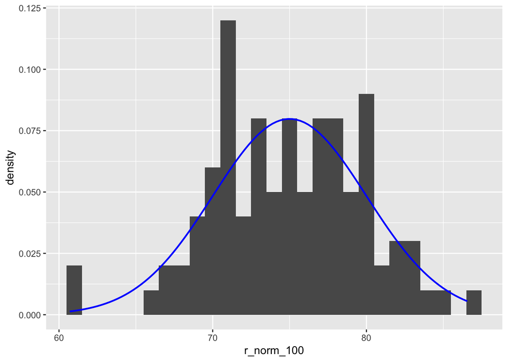

```r
#generate  random normals
r_norm_100 <- rnorm(n = 100, mean = 75, sd = 5)
r_norm_1000 <- rnorm(n = 1000, mean = 75, sd = 5)
r_norm_10000 <- rnorm(n = 10000, mean = 75, sd = 5)
#plot
ggplot(data = data.frame(r_norm_100)) +
  geom_histogram(mapping = aes(x = r_norm_100, y = ..density..), binwidth = 1) +
  stat_function(fun = dnorm, args = list(mean = 75, sd = 5), color = "blue", size = 0.8)
```

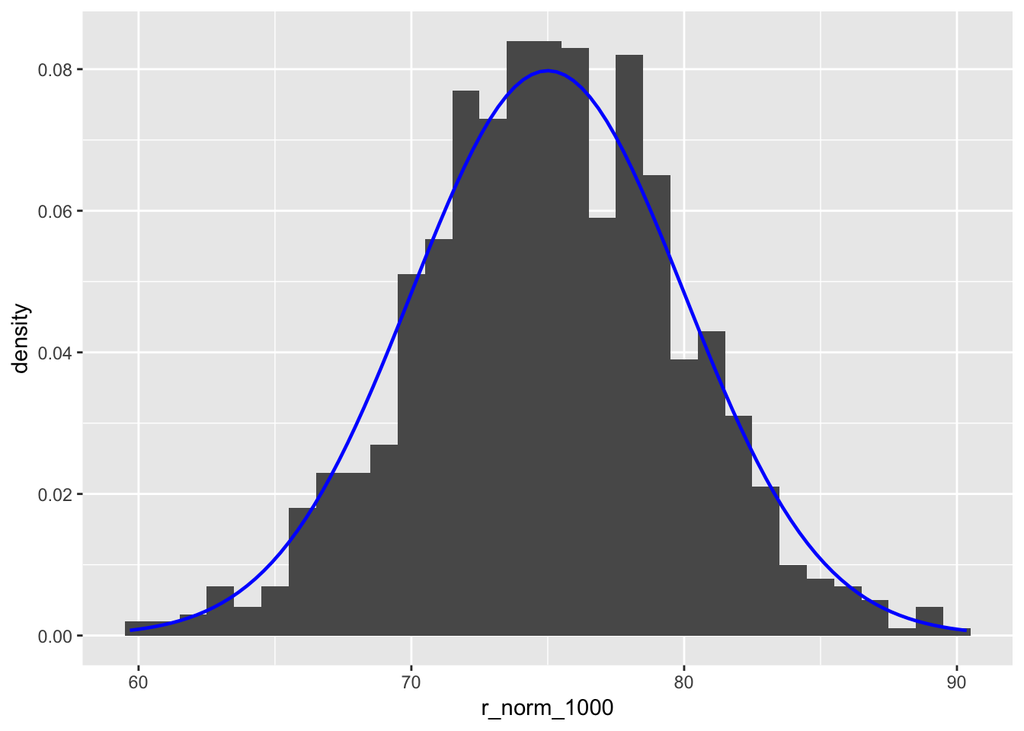

```r
ggplot(data = data.frame(r_norm_1000)) +
  geom_histogram(mapping = aes(x = r_norm_1000, y = ..density..), binwidth = 1) +
  stat_function(fun = dnorm, args = list(mean = 75, sd = 5), color = "blue", size = 0.8)
```

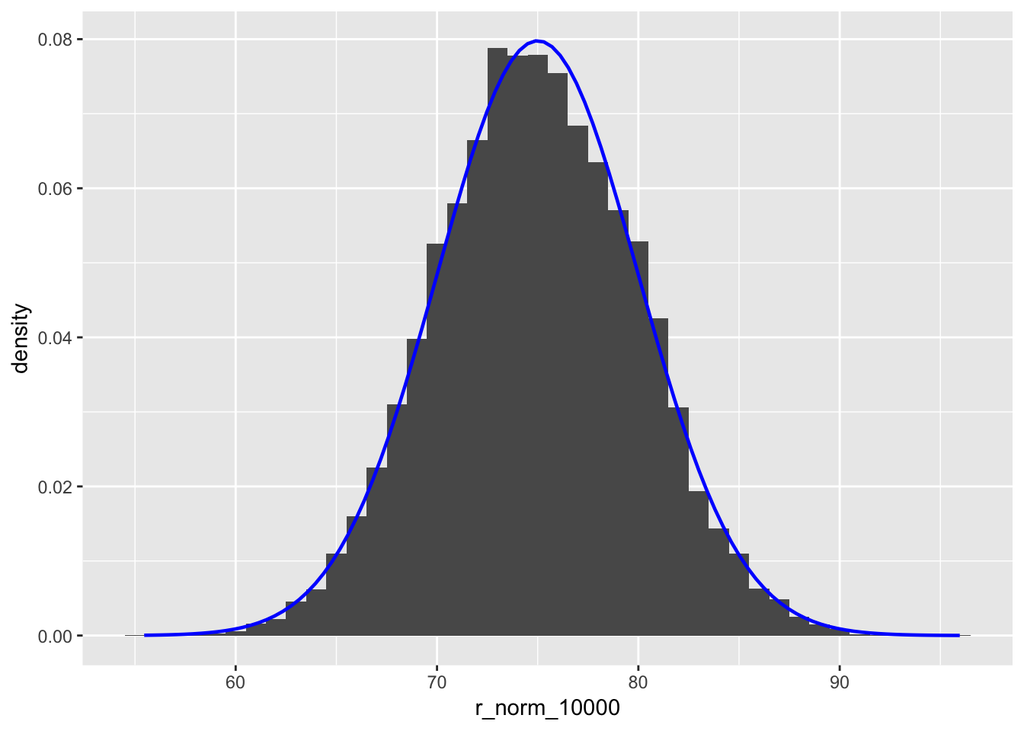

```r
ggplot(data = data.frame(r_norm_10000)) +
  geom_histogram(mapping = aes(x = r_norm_10000, y = ..density..), binwidth = 1) +
  stat_function(fun = dnorm, args = list(mean = 75, sd = 5), color = "blue", size = 0.8)
```

## Usefulness of Generating random numbers in Simulation

# The Uniform Distribution

## The Uniform Distribution Functions in R

```r
dunif(x, min = 0, max = 1, log = FALSE)
punif(q, min = 0, max = 1, lower.tail = TRUE, log.p = FALSE)
qunif(p, min = 0, max = 1, lower.tail = TRUE, log.p = FALSE)
runif(n, min = 0, max = 1)
```

## Plot using dunif and punif

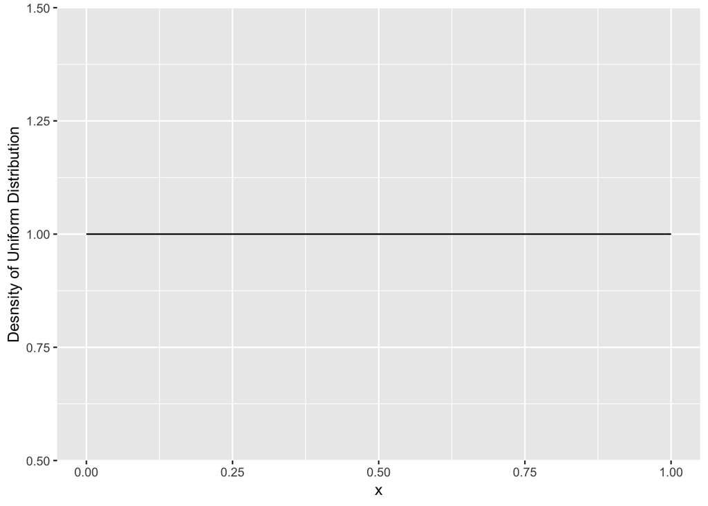

```r
# Uniform density
ggplot(data = data.frame(x = c(0, 1)), aes(x)) +
  stat_function(fun = dunif, args = list(min = 0, max = 1)) +
  ylab("Desnsity of Uniform Distribution")
```

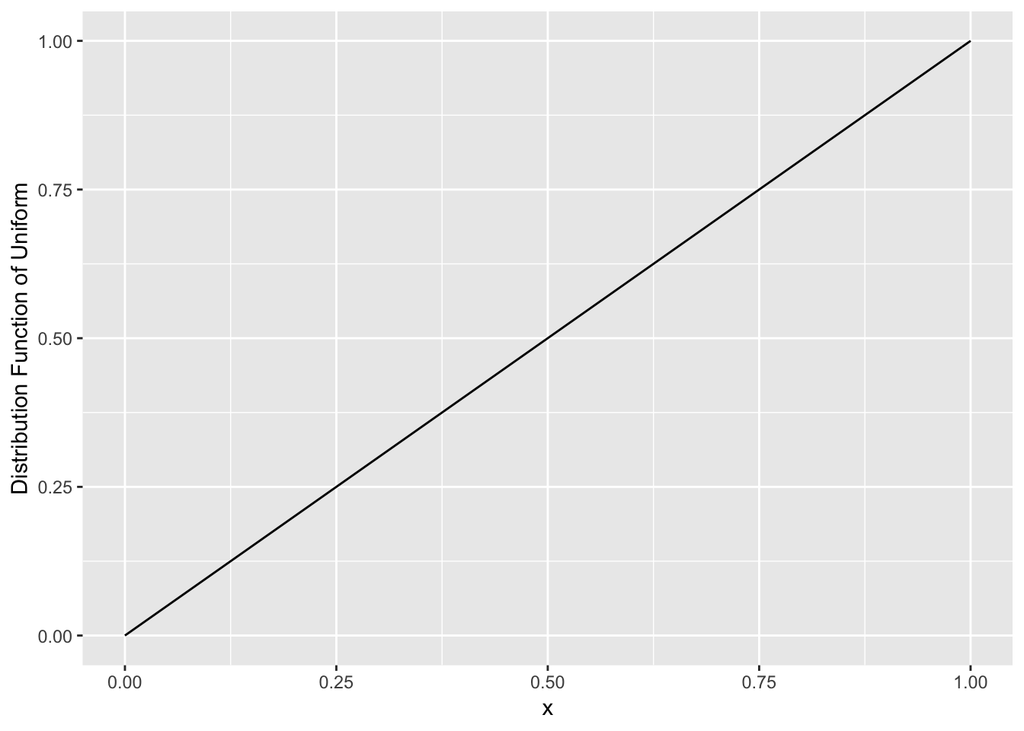

```r
# Plot the distribution function of Uniform
ggplot(data = data.frame(x = c(0, 1)), aes(x)) +
  stat_function(fun = punif, args = list(min = 0, max = 1)) +
  ylab("Distribution Function of Uniform")
```

# The Student t Distribution

## R Functions

```r
dt(x, df, ncp, log = FALSE)
pt(q, df, ncp, lower.tail = TRUE, log.p = FALSE)
qt(p, df, ncp, lower.tail = TRUE, log.p = FALSE)
rt(n, df, ncp)
```

## Comparing t with normal

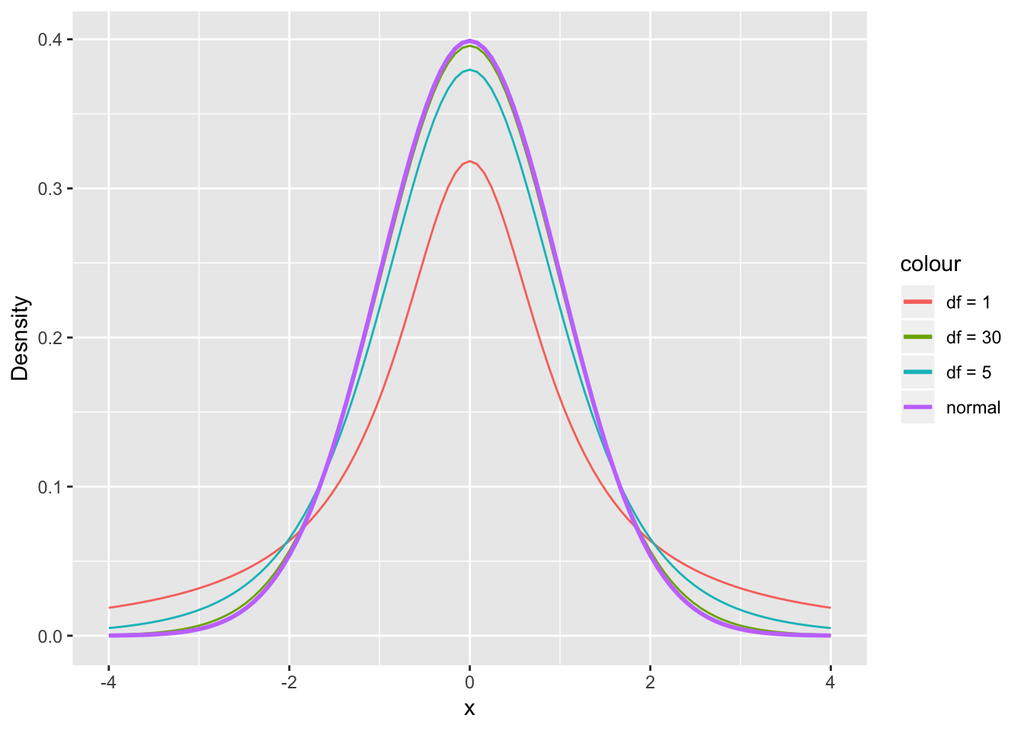

```r
ggplot(data = data.frame(x = c(-4, 4)), aes(x)) +
  stat_function(fun = dt, args = list(df = 1), aes(color = "df = 1")) +
  stat_function(fun = dt, args = list(df = 5), aes(color = "df = 5")) +
  stat_function(fun = dt, args = list(df = 30), aes(color = "df = 30")) +
  stat_function(fun = dnorm, args = list(mean = 0, sd = 1), aes(color = "normal"), size = 1) +
  ylab("Desnsity")
```

## Using pt

```r
# t-stat = 2.3, df = 25
# one-sided pvalue
# P(t > 2.3)
pt(q = 2.3, df =25, lower.tail = FALSE)
```

```
## [1] 0.01503675
```

```r
# two-sided pvalue
pt(q = 2.3, df =25, lower.tail = FALSE) + pt(q = - 2.3, df =25, lower.tail = TRUE)
```

```
## [1] 0.03007351
```

```r
pt(q = 2.3, df =25, lower.tail = FALSE) * 2
```

```
## [1] 0.03007351
```

## Using qp

```r
# find t for 95% confidence interval
# value of t with 2.5% in each tail

qt(p = 0.025, df = 25, lower.tail = TRUE)
```

```
## [1] -2.059539
```

# The Binomial Distribution

## R Function

```r
dbinom(x, size, prob, log = FALSE)
pbinom(q, size, prob, lower.tail = TRUE, log.p = FALSE)
qbinom(p, size, prob, lower.tail = TRUE, log.p = FALSE)
rbinom(n, size, prob)
```

## Plot binomial distribution

[figure not shown]

```r
ggplot(data = NULL,  aes(x, density)) +
  geom_point(data = data.frame(x = 0:40, density = dbinom(0:40,10, 0.5)), aes(color = "n= 20, p = 0.5"), size = 2) +
  geom_point(data = data.frame(x = 0:40, density = dbinom(0:40,40, 0.1)), aes(color = "n= 40, p = 0.1"), size = 2) +
  geom_point(data = data.frame(x = 0:40, density = dbinom(0:40,40, 0.9)), aes(color = "n= 40, p = 0.9"), size = 2) +
  geom_point(data = data.frame(x = 0:40, density = dbinom(0:40,40, 0.5)), aes(color = "n= 40, p = 0.5"), size = 2) +
  scale_color_discrete(h=c(500,900), c=200, l=50)
```

## Example

X is binomially distributed with n = 20 trials and p = 1/6 probability of success. X ~ BIN(n = 20, p = 1/6)

## Using dbinom

```r
# P(x = 3)
dbinom(x = 3, size = 20, prob = 1/6, log = FALSE)
```

```
## [1] 0.2378866
```

```r
# P(x = 0) & P(x = 1) &... & P(x = 3)
dbinom(x = 0:3, size = 20, prob = 1/6)
```

```
## [1] 0.02608405 0.10433621 0.19823881 0.23788657
```

```r
# P(X <= 3)
sum(dbinom(x = 0:3, size = 20, prob = 1/6))
```

```
## [1] 0.5665456
```

```r
pbinom(q = 3, size = 20, prob = 1/6, lower.tail = TRUE)
```

```
## [1] 0.5665456
```

## Using rbinom

```r
rbinom(n = 10, size = 20, prob = 1/6)
```

```
##  [1] 2 2 5 2 3 4 5 4 5 0
```

# The Poisson Distribution

## R Functions

```r
dpois(x, lambda, log = FALSE)
ppois(q, lambda, lower.tail = TRUE, log.p = FALSE)
qpois(p, lambda, lower.tail = TRUE, log.p = FALSE)
rpois(n, lambda)
```

## Using dpois

```r
# P(X = 4)
dpois(x = 4, lambda = 7)
```

```
## [1] 0.09122619
```

```r
# P(x = 0) & P(x = 1) &... & P(x = 4)
dpois(x = 0:4, lambda = 7)
```

```
## [1] 0.000911882 0.006383174 0.022341108 0.052129252 0.091226192
```

```r
# P(X <= 4)
sum(dpois(x = 0:4, lambda = 7))
```

```
## [1] 0.1729916
```

## Using ppois

```r
# P(X <= 4)
ppois(q = 4, lambda = 7, lower.tail = TRUE)
```

```
## [1] 0.1729916
```

```r
# P(X > 4)
ppois(q = 4, lambda = 7, lower.tail = FALSE)
```

```
## [1] 0.8270084
```

## Exercise

学习使用R中卡方分布的四个函数。研究卡方分布的性质，使用ggplot画图表示不同自由度(df)的卡方分布密度函数的形状。

# Other functions for generating random numbers

## To reproduce the results, using set.seed()

```r
rnorm(20, mean = 5, sd = 1)
```

```
##  [1] 5.062053 4.529508 4.848669 5.488205 4.509693 6.702337 6.472334
##  [8] 4.151773 4.314416 5.402053 4.487393 6.387968 6.624775 6.323901
## [15] 4.465283 3.605992 4.717501 1.881494 5.091475 2.925833
```

```r
rnorm(20, mean = 5, sd = 1)
```

```
##  [1] 6.222830 3.100596 5.209429 5.294781 4.469199 6.256035 5.613415
##  [8] 4.143598 6.333135 5.591424 5.431742 5.042922 5.661800 2.851779
## [15] 5.746727 3.815331 4.320932 6.561239 6.535373 6.239141
```

```r
# It produces two different samples randomly
```

```r
set.seed(12345)
rnorm(20, mean = 5, sd = 1)
```

```
##  [1] 5.585529 5.709466 4.890697 4.546503 5.605887 3.182044 5.630099
##  [8] 4.723816 4.715840 4.080678 4.883752 6.817312 5.370628 5.520216
## [15] 4.249468 5.816900 4.113642 4.668422 6.120713 5.298724
```

```r
set.seed(12345)
rnorm(20, mean = 5, sd = 1)
```

```
##  [1] 5.585529 5.709466 4.890697 4.546503 5.605887 3.182044 5.630099
##  [8] 4.723816 4.715840 4.080678 4.883752 6.817312 5.370628 5.520216
## [15] 4.249468 5.816900 4.113642 4.668422 6.120713 5.298724
```

```r
# You get two same random sample when you set the same seeds.
```

## sample()

```r
sample(x, size, replace = FALSE, prob = NULL)

#replace:   should sampling be with replacement?
```

```r
sample(1:10, 5)
```

```
## [1]  8  4 10  6  2
```

```r
sample(1:10, 5)
```

```
## [1]  4  1  9  8 10
```

```r
sample(1:10, 10)
```

```
##  [1] 10  8  3  2  5  9  6  1  4  7
```

```r
sample(1:10, 10, replace = TRUE)
```

```
##  [1]  8  3 10  8 10  3 10  2  7 10
```

```r
sample(letters,5)
```

```
## [1] "r" "m" "i" "h" "b"
```

# Simulation

## Using simulated data to investigate the property of regression

```r
set.seed(12345)
x <- rnorm(100)
e <- rnorm(100, 0, 2)
y <- 0.5 + 2 * x + e
summary(y)
```

```
##    Min. 1st Qu.  Median    Mean 3rd Qu.    Max.
##  -6.848  -1.067   1.109   1.081   3.489   7.715
```

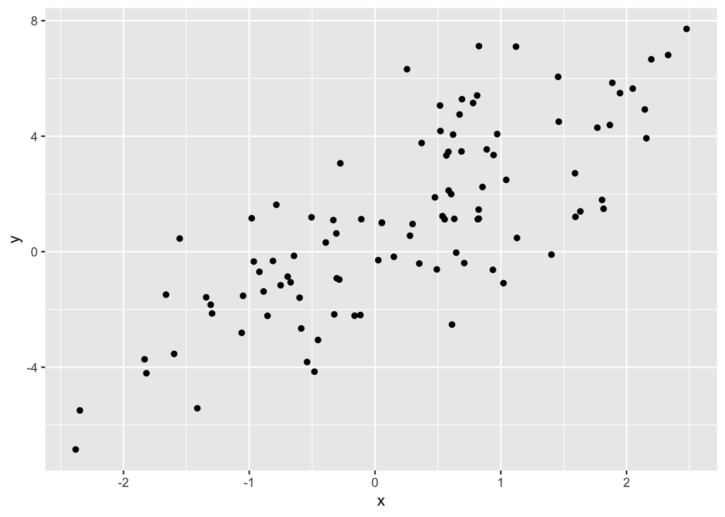

```r
ggplot(data = data.frame(x,y), aes(x,y)) +
  geom_point()
```

```r
summary(lm(y~x))
```

```
##
## Call:
## lm(formula = y ~ x)
##
## Residuals:
##     Min      1Q  Median      3Q     Max
## -4.4069 -1.2056 -0.0223  1.2380  5.2194
##
## Coefficients:
##             Estimate Std. Error t value Pr(>|t|)
## (Intercept)   0.5441     0.2071   2.628  0.00997 **
## x             2.1891     0.1823  12.010  < 2e-16 ***
## ---
## Signif. codes:  0 '***' 0.001 '**' 0.01 '*' 0.05 '.' 0.1 ' ' 1
##
## Residual standard error: 2.022 on 98 degrees of freedom
## Multiple R-squared:  0.5954, Adjusted R-squared:  0.5913
## F-statistic: 144.2 on 1 and 98 DF,  p-value: < 2.2e-16
```

# Understanding the central limit theorem by Simulation

The central limit theorem (CLT) states that if $X_i$ are drawn independently from a population where µ and σ are known, then the standardized average is asymptotically normal with mean 0 and variance 1 (often called normal(0,1)).

That is, if n is large enough the average is approximately normal with mean $µ$ and standard deviation $σ/sqrt(n)$.

## CLT with normal data

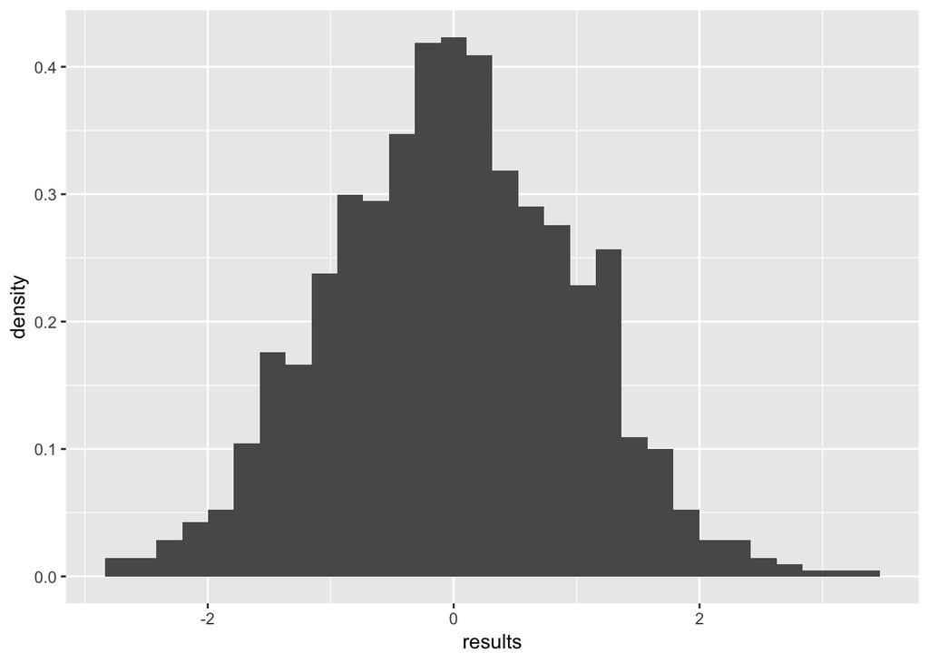

```r
results = vector("double", 1000)
mu = 0; sigma = 1

for(i in 1:1000) {
  X <- rnorm(10,mu,sigma)
# generate random data
  results[i] = (mean(X) - mu)/(sigma/sqrt(10))
}
ggplot(data = data.frame(results), aes(x = results, y = ..density..)) +
  geom_histogram()
```

## CLT with uniform data

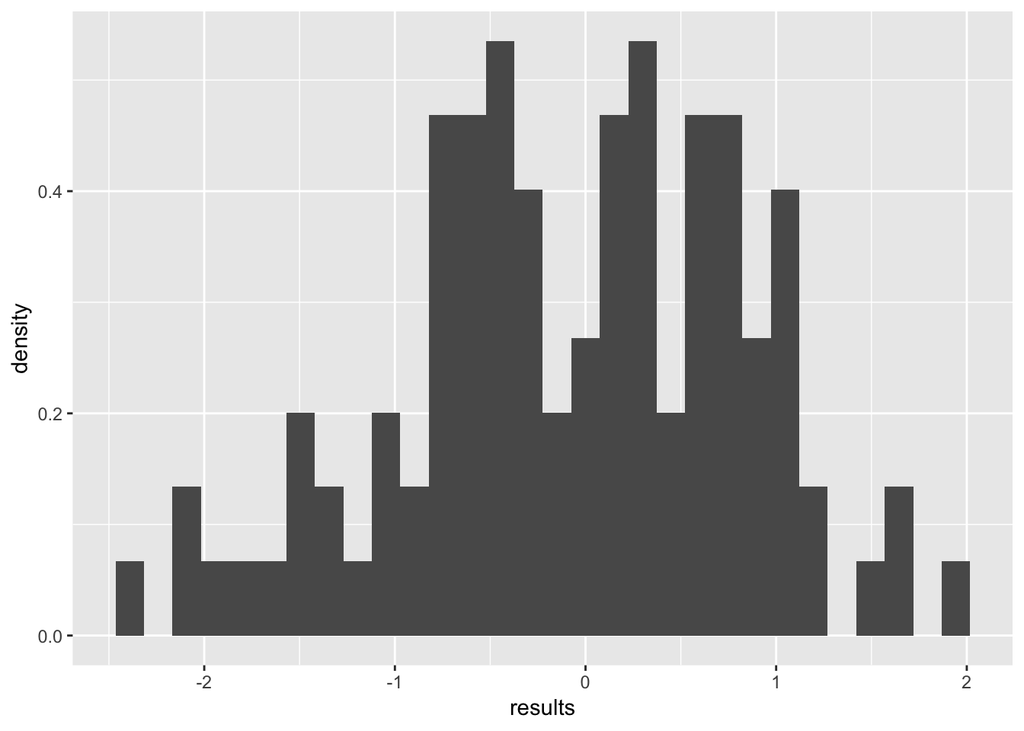

```r
results = vector("double",100)

# mean = (a + b)/2; variance = (b - a)^2/12
mu <- 1/2; sigma <- sqrt(1/12)

for(i in 1:100) {
  X <- runif(10)
  # generate random data
  results[i] = (mean(X) - mu)/(sigma/sqrt(10))
}
ggplot(data = data.frame(results), aes(x = results, y = ..density..)) +
  geom_histogram()
```

```r
n_draws <- c(100, 1000, 5000, 10000)
n_each_draw <- 10

# mean = (a + b)/2; variance = (b - a)^2/12
mu <- 1/2; sigma <- sqrt(1/12)

list_results <- vector("list", 4)
plot_list <- vector("list", 4)
for (j in 1:4) {
  results = vector("double", n_draws[j])
  for(i in 1:n_draws[j]) {
    X <- runif(10)
    # generate random data
    results[i] = (mean(X) - mu)/(sigma/sqrt(10))
  }
  list_results[[j]] <-
    ggplot(data = data.frame(results), aes(x = results, y = ..density..)) +
      geom_histogram()+xlab(paste('n_draw equals',n_draws[j]) )
}
```

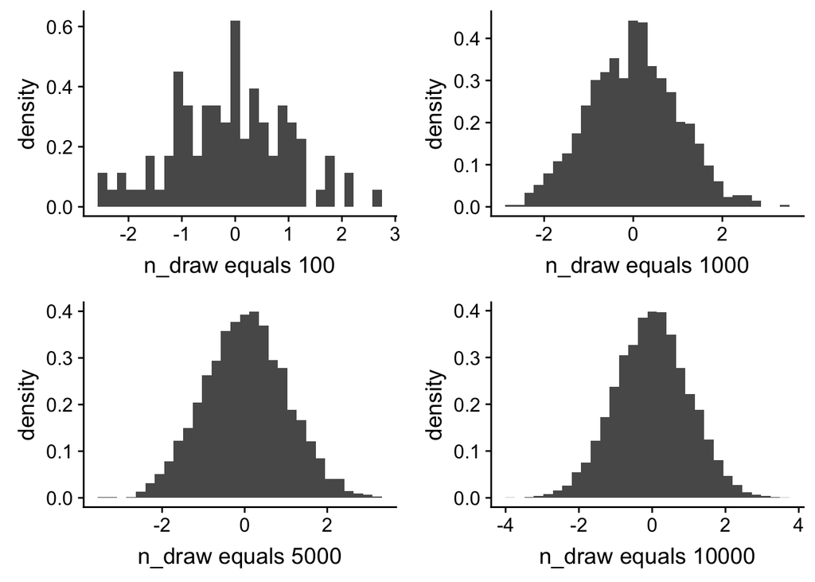

```r
library(cowplot)
plot_grid(plotlist=list_results)
```

# Understanding Confidence Interval with Simulation

## What does CI mean?

```r
is_include <- vector("logical", 10000)

for (i in 1:10000) {
  half_alpha <- qnorm(0.025)
  conf_int <- mean(rnorm(100)) + (1/sqrt(100)) * c(half_alpha, -half_alpha)
  is_include[i] <- ifelse (conf_int[1] < 0 & conf_int[2] > 0, TRUE, FALSE)
}

sum(!is_include)
```

```
## [1] 493
```

```r
# this sum value should be around 500 since we take the significance level of 5%
```

# Exercise

## 1

若样本来自指数分布，写代码说明中心极限定理仍然是成立的。可以像课件中的例子一样简单地用histogram说明分布的正态性，但推荐自学正态性检验地方法，最简单地是Q-Q图，更严格的有各种统计检验方法，如KS (Kolmogorov-Smirnov) test,shapiro-wilk检验,Anderson-Darling 检验等, R语言中有这些检验函数。

##2 写一个函数，通过模拟（Simulation） 来验证样本均值的置信区间的含义。要求如下：

1 总体的标准差(sigma)是未知的。

2 要能保存生成的每一个置信区间（长度为2的数值型向量），以及总体均值是否在该置信区间中（逻辑型）。提示：返回的数据结构是dataframe。

3 调用该函数时，用for循环和map() 函数两种方法。

4 研究循环次数（如100次，1000次，10000次，100000次）对输出结果有什么影响，最好能绘图表示。提示：为了能更清晰地展现循环次数对结果的影响，你应当尽可能尝试更多的实验。

# One-Sample t Test in R

The one sample t-test and confidence interval are parametric memthods approporiate for examing a single numeric variable.

## Data

```r
library(readxl)
library(readxl)
data_lung <- read_excel("/Users/wuyuhe/Desktop/WHU/Data_Processing/LungCapData.xls")
data_lung
```

```
## # A tibble: 725 x 6
##    LungCap   Age Height Smoke Gender Caesarean
##      <dbl> <dbl>  <dbl> <chr> <chr>  <chr>
##  1    6.48     6   62.1 no    male   no
##  2   10.1     18   74.7 yes   female no
##  3    9.55    16   69.7 no    female yes
##  4   11.1     14   71   no    male   no
##  5    4.8      5   56.9 no    male   no
##  6    6.22    11   58.7 no    female no
##  7    4.95     8   63.3 no    male   yes
##  8    7.32    11   70.4 no    male   no
##  9    8.88    15   70.5 no    male   no
## 10    6.8     11   59.2 no    male   no
## # ... with 715 more rows
```

```r
attach(data_lung)
```

## Summary statistics for variable LungCap

```r
library(stats)
mean(data_lung$LungCap)
```

```
## [1] 7.863148
```

```r
sd(data_lung$LungCap)
```

```
## [1] 2.662008
```

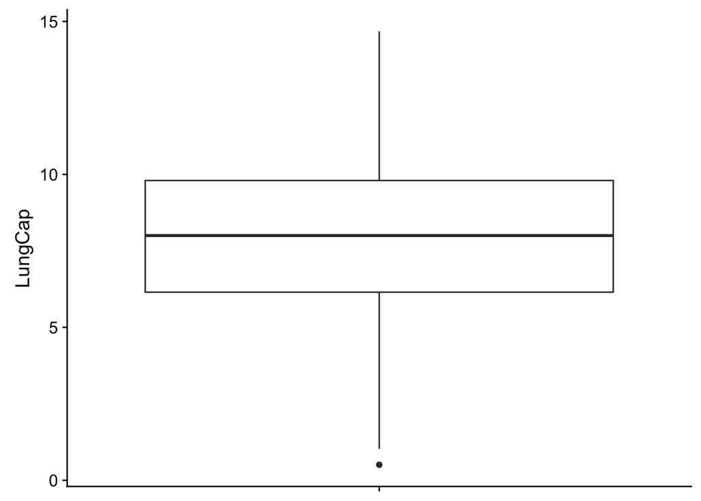

```r
library(ggplot2)
ggplot(data = data_lung, mapping = aes( x = factor(0), y = LungCap)) +
  geom_boxplot() +
  theme(axis.title.x=element_blank(),
        axis.text.x=element_blank())
```

```r
# Obviously, from the following plot, the varible LungCap clusters around 8, the mean value of it. The boxplot also
# shows the maximun, min and quantile values of LungCap.
```

## t.test()

```r
t.test(x, y = NULL,
       alternative = c("two.sided", "less", "greater"),
       mu = 0, paired = FALSE, var.equal = FALSE,
       conf.level = 0.95, ...)
```

The one-sample t test is for testing whether the data has significant differnece with its mean value. That is to say, it is used to examine whether the data gathers around the mean value or it relatively scatters. To better illustrate this point, we use the following two samples:

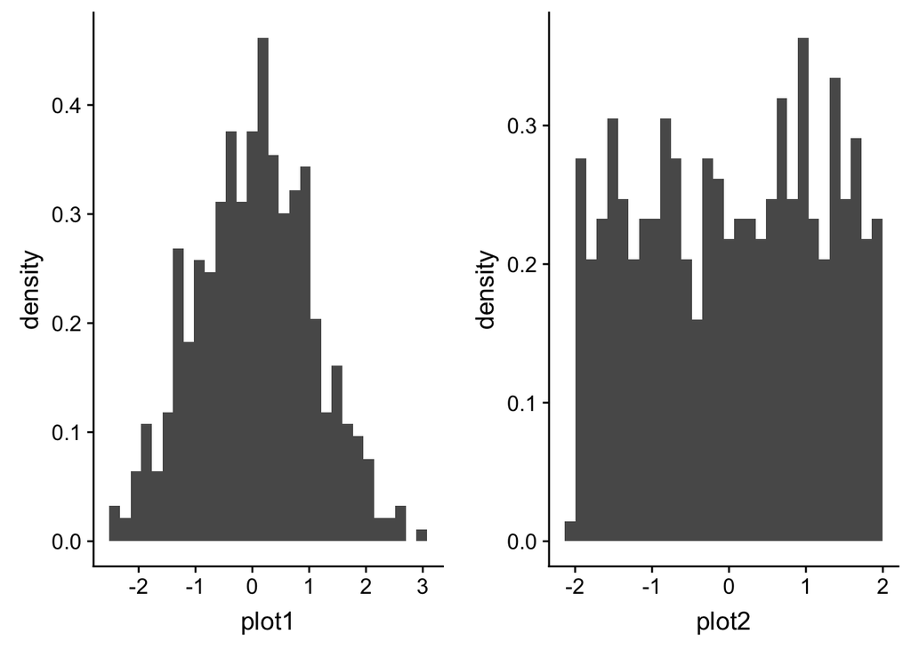

The two plots above shows two datasets with the same mean value 0. However, all the data in $x_1$ gathers around 0 in plot1 while $x_2$ spreads much evenly in plot2. Therefore, the variance of $x_1$ should be smaller than the variane of $x_2$.

The t statistics is calculated as
$$t = \frac{x-\mu(x)}{se(x)}$$
, thus t1 should be bigger than t2. By one-sample t test, we say a dataset significantly different from the mean value at a specific significance level if the absolute value of t statistics is larger than the that of the critical value, or the t statistics locats outside the confidence interval.

```r
# H1: mu < 8
# one-sided 95% confidence interval for mu
t.test(LungCap, mu = 8, alt = "less", conf.level = 0.95)
```

```
##
##  One Sample t-test
##
## data:  LungCap
## t = -1.3842, df = 724, p-value = 0.08336
## alternative hypothesis: true mean is less than 8
## 95 percent confidence interval:
##      -Inf 8.025974
## sample estimates:
## mean of x
##  7.863148
```

```r
# The result below indicates that the variable LungCap is not significantly differenct #from 8 since the p-value of the t statistics is larger than 0.05
```

```r
# two-sided, default
t.test(LungCap, mu = 8, alt = "two.sided", conf.level = 0.95)
```

```
##
##  One Sample t-test
##
## data:  LungCap
## t = -1.3842, df = 724, p-value = 0.1667
## alternative hypothesis: true mean is not equal to 8
## 95 percent confidence interval:
##  7.669052 8.057243
## sample estimates:
## mean of x
##  7.863148
```

```r
# try to interpret this result by yourself!
```

# Understanding t.test()

```r
my_test <- t.test(LungCap, mu = 8, conf.level = 0.99)
```

## Structure and Attributes

```r
str(my_test)
```

```
## List of 9
##  $ statistic  : Named num -1.38
##   ..- attr(*, "names")= chr "t"
##  $ parameter  : Named num 724
##   ..- attr(*, "names")= chr "df"
##  $ p.value    : num 0.167
##  $ conf.int   : atomic [1:2] 7.61 8.12
##   ..- attr(*, "conf.level")= num 0.99
##  $ estimate   : Named num 7.86
##   ..- attr(*, "names")= chr "mean of x"
##  $ null.value : Named num 8
##   ..- attr(*, "names")= chr "mean"
##  $ alternative: chr "two.sided"
##  $ method     : chr "One Sample t-test"
##  $ data.name  : chr "LungCap"
##  - attr(*, "class")= chr "htest"
```

```r
attributes(my_test)
```

```
## $names
## [1] "statistic"   "parameter"   "p.value"     "conf.int"    "estimate"
## [6] "null.value"  "alternative" "method"      "data.name"
##
## $class
## [1] "htest"
```

## Extract elements

```r
my_test$p.value
```

```
## [1] 0.1667108
```

```r
my_test$conf.int
```

```
## [1] 7.607816 8.118479
## attr(,"conf.level")
## [1] 0.99
```

```r
my_test$estimate
```

```
## mean of x
##  7.863148
```

```r
my_test$method
```

```
## [1] "One Sample t-test"
```

# Constructing confidence interval and Calculating the p-value of t-test

```r
# parameters
n <- nrow(data_lung)
conf_level = 0.95

#sample mean
x_bar <- mean(LungCap)
#standard error
std_err <- sd(LungCap)/sqrt(n)

#get the quantile accoding to probability
alpha_lower <- qt(p = (1 - conf_level)/2, df = n - 1, lower.tail = TRUE)
alpha_upper <- qt(p = (1 - conf_level)/2, df = n - 1, lower.tail = FALSE)

#construct confidence intervals
(conf_int <- x_bar + std_err * c(alpha_lower, alpha_upper) )
```

```
## [1] 7.669052 8.057243
```

```r
#t_value: (x_bar - mu)/std_err ~ t(df)
t_value <- (x_bar - 8 )/std_err
pt(q = t_value,  df = n - 1, lower.tail = TRUE) * 2
```

```
## [1] 0.1667108
```

```r
# Comparing to the built-in function
t.test(LungCap, mu = 8, alt = "two.sided", conf.level = 0.95)
```

```
##
##  One Sample t-test
##
## data:  LungCap
## t = -1.3842, df = 724, p-value = 0.1667
## alternative hypothesis: true mean is not equal to 8
## 95 percent confidence interval:
##  7.669052 8.057243
## sample estimates:
## mean of x
##  7.863148
```

# Two sample t-test

The two sample t-test is generally used to test whether the mean values of two datasets are significantly different from each other or, whether the difference in means for two populations is signifanct enough.

```r
unique(Smoke)
```

```
## [1] "no"  "yes"
```

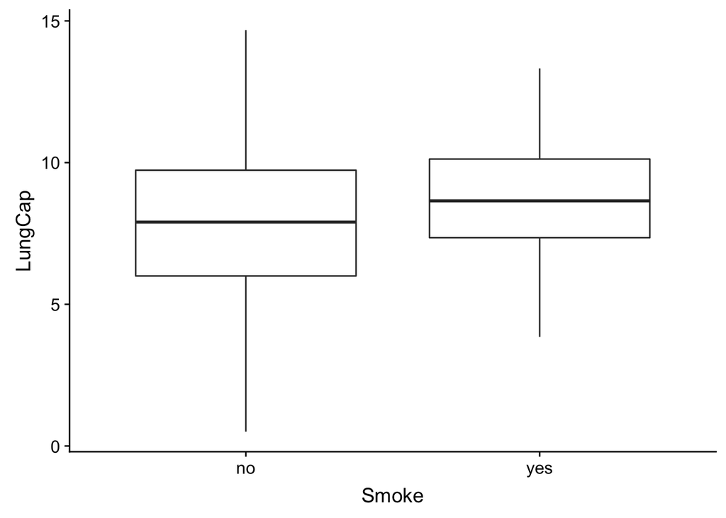

```r
#boxplot
ggplot(data = data_lung, aes(x = Smoke, y = LungCap)) +
  geom_boxplot()
```

```r
library(dplyr)
data_lung %>%
  group_by(Smoke) %>%
  summarise(n = n(), x_bar = mean(LungCap), sd_bar = sd(LungCap), std_err=sd_bar/sqrt(n))
```

```
## # A tibble: 2 x 5
##   Smoke     n x_bar sd_bar std_err
##   <chr> <int> <dbl>  <dbl>   <dbl>
## 1 no      648  7.77   2.73   0.107
## 2 yes      77  8.65   1.88   0.215
```

## 2-sample t-test for LungCap of smokers = of non smokers

```r
# two-sided t test
# assume non-equal variances based on the summary statistics above

t.test(LungCap ~ Smoke, mu = 0, alt = "two.sided", conf = 0.95, var.eq = FALSE, paired = FALSE)
```

```
##
##  Welch Two Sample t-test
##
## data:  LungCap by Smoke
## t = -3.6498, df = 117.72, p-value = 0.0003927
## alternative hypothesis: true difference in means is not equal to 0
## 95 percent confidence interval:
##  -1.3501778 -0.4003548
## sample estimates:
##  mean in group no mean in group yes
##          7.770188          8.645455
```

```r
# all arguments above are default value
# t.test(LungCap ~ Smoke)

#another method
t.test(LungCap[Smoke == "no"], LungCap[Smoke == "yes"])
```

```
##
##  Welch Two Sample t-test
##
## data:  LungCap[Smoke == "no"] and LungCap[Smoke == "yes"]
## t = -3.6498, df = 117.72, p-value = 0.0003927
## alternative hypothesis: true difference in means is not equal to 0
## 95 percent confidence interval:
##  -1.3501778 -0.4003548
## sample estimates:
## mean of x mean of y
##  7.770188  8.645455
```

```r
#what if assuming the equal variances
t.test(LungCap ~ Smoke, mu = 0, alt = "two.sided", conf = 0.95, var.eq = TRUE, paired = FALSE)
```

```
##
##  Two Sample t-test
##
## data:  LungCap by Smoke
## t = -2.7399, df = 723, p-value = 0.006297
## alternative hypothesis: true difference in means is not equal to 0
## 95 percent confidence interval:
##  -1.5024262 -0.2481063
## sample estimates:
##  mean in group no mean in group yes
##          7.770188          8.645455
```